# Assignment 2

## Hierarchical clustering

Perform hierarchical clustering on the same proteomic data.

Choose a suitable distance metric and linkage method.

Determine the optimal number of clusters.

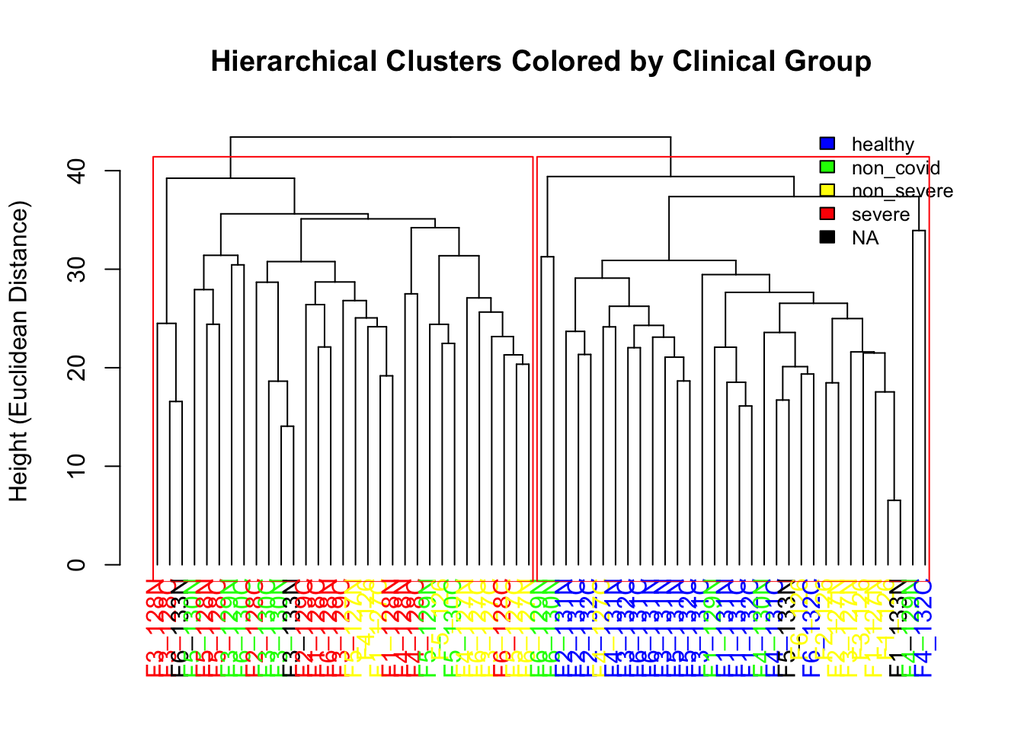

```r
# Dissimilarity matrix
group_colors <- c(
  "healthy"    = "blue",  # Blue
  "non_covid"  = "green",  # Teal
  "non_severe" = "yellow",  # Yellow
  "severe"     = "red"   # Red
)
df1$color <- group_colors[as.character(df1$Group)]
d_mat <- dist(df2_scaled, method = "euclidean")

# Perform the clustering
hcl <- hclust(d_mat, method = "complete")

# Prepare the plot including clinical information
dend <- as.dendrogram(hcl)
dend_labels <- labels(dend)
ordered_colors <- df1$color[match(dend_labels, df1$MS_ID_b)]
labels_colors(dend) <- ordered_colors
plot(dend,
     main = "Hierarchical Clusters Colored by Clinical Group",
     ylab = "Height (Euclidean Distance)",
     cex = 0.6)

legend("topright",
       legend = c(names(group_colors), "NA"),
       fill = c(group_colors, "black"),
       bty = "n",
       cex = 0.8)

rect.hclust(hcl, k = 2, border = "red")
```

```r
hc_clusters <- cutree(hcl, k = 2)
print(table(hc_clusters))
```

```
## hc_clusters
##  1  2
## 32 31
```

## Comparison of clustering results

Compare the cluster assignments obtained from k-means and hierarchical clustering.

Assess the concordance between the two methods.

Evaluate whether patients group according to disease severity, despite severity not being used to define the clusters.

> We can observe that, despite their different nature, both types of clustering produced similar results. The same patterns can be seen both in the k-means and hierarchical clusters.

> In both of them, we can conclude that disease severity is differentiated through the clusters despite it wasn’t used to define the clusters. It is true that there were not four different clusters according to the four clinical groups, but, still, some patters were obtained. We can see how the healthy patients are clustered together in cluster 1 and the COVID-19 Severe patients in cluster 2 in the k-means results, while the other two groups (Non-COVID-19 and Non-severe) appear in both clusters. Therefore, we can conclude that the clusters clearly differentiate healthy and severe patients, indicating that they have significant proteomic differences. The Non-COVID and non-severe patients have proteomics with less significant differences with respect to the other groups, so they appear in both clusters and not necessarily grouped together.

> The results in the hierarchical clusters lead to the same conclusions or even better. While one healthy patient appeared in cluster 2 in the k-means plot, now all of them appear in the same hierarchical cluster, highlighting even more that the clusters grouped both the healthy and severe patients together, respectively.

# Exercise 2: Dimensionality reduction

In this exercise, you will apply dimensionality reduction techniques to visualize the structure of the proteomic data and identify the main sources of variance.

## Principal Component Analysis (PCA)

Perform PCA on the proteomic dataset.

Generate a figure similar to Figure S2, panel B, but using PCA. Color the samples by disease severity.

Answer the following questions:

- Which proteins contribute most strongly to principal component 1 (PC1)? (top 20)
- Which proteins contribute most strongly to principal component 2 (PC2)? (top 20)
- What biological or clinical factors appear to drive the variance along PC1?
- What is driving the variance along PC2?

> In this part we perform PCA to the proteomic dataset, using again the information in the patient metadata table, in order to generate a figure similar to Figure 2, panel B.

> The code starts by preparing the data from both tables and then it performs the PCA and generates the corresponding figures. To end up, it includes the plots required to answer the provided questions.

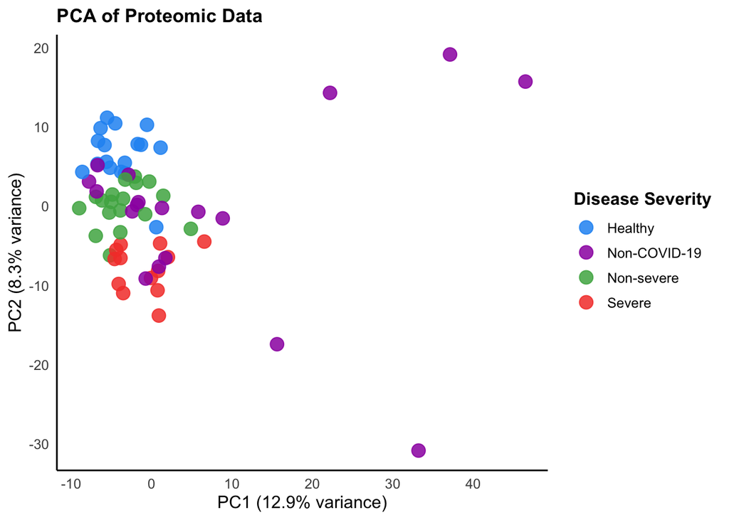

```r
# --- DATA LOADING AND PREPROCESSING ---
raw <- read_excel("table_s2.xlsx", sheet = "Proteomics_proteins_training", col_names = FALSE)

ms_ids <- as.character(unlist(raw[2, 3:ncol(raw)]))
ms_ids <- ms_ids[!is.na(ms_ids)]
n_samples <- length(ms_ids)

protein_ids_gene <- as.character(unlist(raw[3:nrow(raw), 2]))
protein_ids_uniprot <- as.character(unlist(raw[3:nrow(raw), 1]))
protein_ids <- ifelse(is.na(protein_ids_gene) | protein_ids_gene == "NA", protein_ids_uniprot, protein_ids_gene)

protein_matrix <- raw[3:nrow(raw), 3:(2 + n_samples)]
protein_matrix <- as.data.frame(lapply(protein_matrix, as.numeric))

protein_matrix_t <- t(protein_matrix)
rownames(protein_matrix_t) <- ms_ids
colnames(protein_matrix_t) <- protein_ids

clinical <- read_excel("table_s1.xlsx", sheet = "Clinical_information")
severity_map <- c("0" = "Healthy", "1" = "Non-COVID-19", "2" = "Non-severe", "3" = "Severe")
clinical$Severity <- severity_map[as.character(clinical$`Group d`)]

ms_to_severity <- setNames(clinical$Severity, clinical$`MS ID b`)
ms_to_patient <- setNames(clinical$`Patient ID a`, clinical$`MS ID b`)

replicate_ids <- c("F1_133N", "F3_133N", "F5_133N", "F6_133N")
keep_samples <- rownames(protein_matrix_t)[!rownames(protein_matrix_t) %in% replicate_ids]
keep_samples <- keep_samples[keep_samples %in% names(ms_to_severity)]
keep_samples <- keep_samples[!is.na(ms_to_severity[keep_samples])]

protein_matrix_t <- protein_matrix_t[keep_samples, ]

col_means <- colMeans(protein_matrix_t, na.rm = TRUE)
for (i in 1:ncol(protein_matrix_t)) {
  nas <- is.na(protein_matrix_t[, i])
  if (any(nas)) protein_matrix_t[nas, i] <- col_means[i]
}

col_var <- apply(protein_matrix_t, 2, var, na.rm = TRUE)
col_sd <- apply(protein_matrix_t, 2, sd, na.rm = TRUE)
protein_matrix_clean <- protein_matrix_t[, col_var > 1e-10 & col_sd > 1e-10 & !is.na(col_var)]
protein_matrix_clean <- protein_matrix_clean[, apply(protein_matrix_clean, 2, function(x) length(unique(x)) > 1)]
protein_matrix_clean <- protein_matrix_clean[, grepl("^[A-Z][A-Z0-9]", colnames(protein_matrix_clean))]

sample_severity <- ms_to_severity[rownames(protein_matrix_clean)]
severity_colors <- c("Healthy" = "#2196F3", "Non-COVID-19" = "#9C27B0", "Non-severe" = "#4CAF50", "Severe" = "#F44336")

# PCA
pca_result <- prcomp(protein_matrix_clean, scale. = TRUE, center = TRUE)
var_explained <- summary(pca_result)$importance[2, ] * 100

pca_data <- data.frame(
  PC1 = pca_result$x[, 1],
  PC2 = pca_result$x[, 2],
  Sample = rownames(pca_result$x),
  Severity = sample_severity[rownames(pca_result$x)]
)
pca_data <- pca_data[!is.na(pca_data$Severity), ]

p_pca <- ggplot(pca_data, aes(x = PC1, y = PC2, color = Severity)) +
  geom_point(size = 4, alpha = 0.85) +
  scale_color_manual(values = severity_colors) +
  theme_minimal(base_size = 12) +
  theme(
    panel.background = element_rect(fill = "white", color = NA),
    plot.background = element_rect(fill = "white", color = NA),
    panel.grid.major = element_blank(),
    panel.grid.minor = element_blank(),
    axis.line = element_line(color = "black"),
    plot.title = element_text(face = "bold", size = 13),
    legend.title = element_text(face = "bold")
  ) +
  labs(
    title = "PCA of Proteomic Data",
    x = paste0("PC1 (", round(var_explained[1], 1), "% variance)"),
    y = paste0("PC2 (", round(var_explained[2], 1), "% variance)"),
    color = "Disease Severity"
  )
print(p_pca)
```

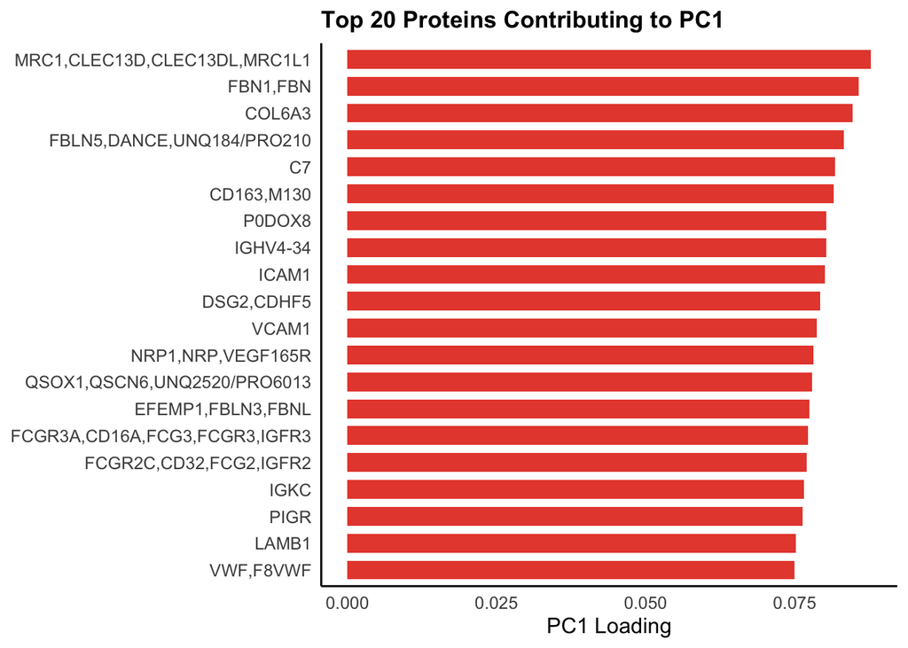

```r
loadings <- as.data.frame(pca_result$rotation)

pc1_order <- order(abs(loadings[, 1]), decreasing = TRUE)[1:20]
top20_pc1 <- data.frame(Protein = rownames(loadings)[pc1_order], Loading = loadings[pc1_order, 1])
top20_pc1 <- top20_pc1[order(top20_pc1$Loading), ]
top20_pc1$Protein <- factor(top20_pc1$Protein, levels = top20_pc1$Protein)
top20_pc1$Direction <- ifelse(top20_pc1$Loading > 0, "Positive", "Negative")

p_pc1 <- ggplot(top20_pc1, aes(x = Protein, y = Loading, fill = Direction)) +
  geom_col(width = 0.7) +
  coord_flip() +
  scale_fill_manual(values = c("Positive" = "#E74C3C", "Negative" = "#3498DB"), guide = "none") +
  theme_minimal(base_size = 12) +
  theme(
    panel.background = element_rect(fill = "white", color = NA),
    plot.background = element_rect(fill = "white", color = NA),
    panel.grid.major = element_blank(),
    panel.grid.minor = element_blank(),
    axis.line = element_line(color = "black"),
    plot.title = element_text(face = "bold", size = 13),
    legend.title = element_text(face = "bold")
  ) +
  labs(title = "Top 20 Proteins Contributing to PC1", x = NULL, y = "PC1 Loading")
print(p_pc1)
```

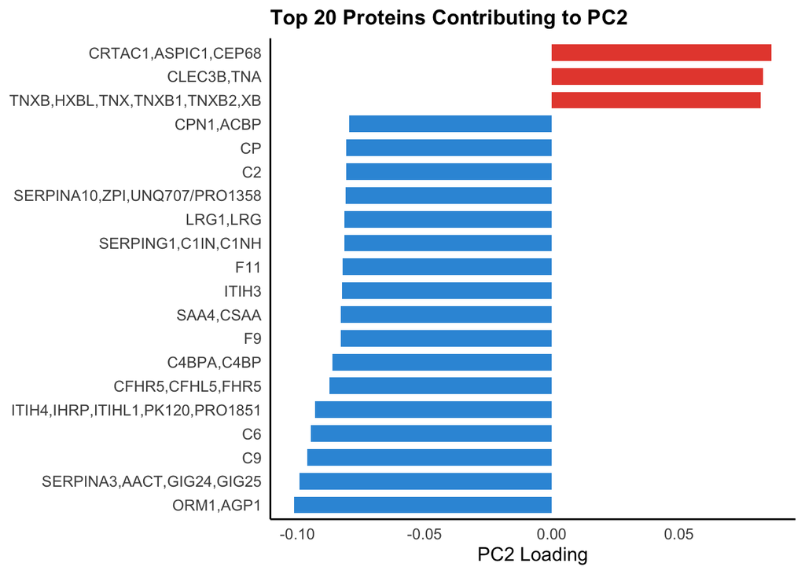

```r
pc2_order <- order(abs(loadings[, 2]), decreasing = TRUE)[1:20]
top20_pc2 <- data.frame(Protein = rownames(loadings)[pc2_order], Loading = loadings[pc2_order, 2])
top20_pc2 <- top20_pc2[order(top20_pc2$Loading), ]
top20_pc2$Protein <- factor(top20_pc2$Protein, levels = top20_pc2$Protein)
top20_pc2$Direction <- ifelse(top20_pc2$Loading > 0, "Positive", "Negative")

p_pc2 <- ggplot(top20_pc2, aes(x = Protein, y = Loading, fill = Direction)) +
  geom_col(width = 0.7) +
  coord_flip() +
  scale_fill_manual(values = c("Positive" = "#E74C3C", "Negative" = "#3498DB"), guide = "none") +
  theme_minimal(base_size = 12) +
  theme(
    panel.background = element_rect(fill = "white", color = NA),
    plot.background = element_rect(fill = "white", color = NA),
    panel.grid.major = element_blank(),
    panel.grid.minor = element_blank(),
    axis.line = element_line(color = "black"),
    plot.title = element_text(face = "bold", size = 13),
    legend.title = element_text(face = "bold")
  ) +
  labs(title = "Top 20 Proteins Contributing to PC2", x = NULL, y = "PC2 Loading")
print(p_pc2)
```

> The first plot in this section corresponds to our replication of Figure S2, panel B from the manuscript. The other two plots answer to the questions about the top 20 proteins contributing to both principal components (PCs).

> The plots show these top 20 proteins contributing to PC1 and PC2 ranked, also indicating if they have positive (red) or negative (blue) loadings. If a protein has a positive loading, it will be pushed to the right side of that PC axis. If it is negative, it will be pushed to the left side. We can observe that, for PC1, all of the top contributing proteins have positive loadings. On the other hand, for PC2, only the top 3 have positive loadings, while the rest have negative ones. Most of the proteins driving variance along PC2 are classical acute-phase, complement, and coagulation pathway proteins, which are strongly linked to systemic inflammation and immune activation.

> Looking at the PCA scatter plot, we can also analyze what drives variance among the two PCA axis. PC1 mainly separates some of the non-COVID patients from the rest. However, they could be considered outliers, because no significant difference is seen between the rest of the patients among PC1. On the other hand, severity drives the variance among PC2. The same behavior seen in the clusters of exercise 1 is observed here. All the healthy patients appear higher in the PC2 axis, while the severe patients appear lower. Again, the Non-COVID-19 and non-sever patients appear in the middle the other two groups, therefore the same conclusions as the ones in exercise 1 can be obtained.

## t-SNE

Perform t-SNE on the proteomic data. Run the analysis using two different perplexity values. Visualize the results, coloring samples by disease severity.

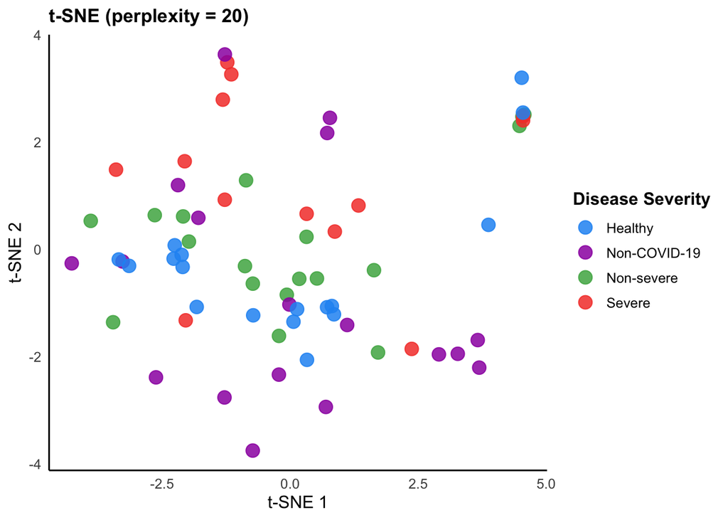

```r
set.seed(42)
n_samples_tsne <- nrow(protein_matrix_clean)
max_perp <- floor((n_samples_tsne - 1) / 3) - 1
perp_high <- min(20, max_perp)
perp_low <- min(10, max_perp)

tsne_high <- Rtsne(protein_matrix_clean, perplexity = perp_high, verbose = FALSE, max_iter = 1000, pca = FALSE)
tsne_low <- Rtsne(protein_matrix_clean, perplexity = perp_low, verbose = FALSE, max_iter = 1000, pca = FALSE)

tsne_df_high <- data.frame(tSNE1 = tsne_high$Y[, 1], tSNE2 = tsne_high$Y[, 2], Sample = rownames(protein_matrix_clean))
tsne_df_high$Severity <- sample_severity[tsne_df_high$Sample]
tsne_df_high <- tsne_df_high[!is.na(tsne_df_high$Severity), ]

tsne_df_low <- data.frame(tSNE1 = tsne_low$Y[, 1], tSNE2 = tsne_low$Y[, 2], Sample = rownames(protein_matrix_clean))
tsne_df_low$Severity <- sample_severity[tsne_df_low$Sample]
tsne_df_low <- tsne_df_low[!is.na(tsne_df_low$Severity), ]

make_tsne_plot <- function(df, perp_val) {
  ggplot(df, aes(x = tSNE1, y = tSNE2, color = Severity)) +
    geom_point(size = 4, alpha = 0.85) +
    scale_color_manual(values = severity_colors) +
    theme_minimal(base_size = 12) +
  theme(
    panel.background = element_rect(fill = "white", color = NA),
    plot.background = element_rect(fill = "white", color = NA),
    panel.grid.major = element_blank(),
    panel.grid.minor = element_blank(),
    axis.line = element_line(color = "black"),
    plot.title = element_text(face = "bold", size = 13),
    legend.title = element_text(face = "bold")
  ) +
    labs(
      title = paste0("t-SNE (perplexity = ", perp_val, ")"),
      x = "t-SNE 1", y = "t-SNE 2", color = "Disease Severity"
    )
}

p_tsne_high <- make_tsne_plot(tsne_df_high, perp_high)
p_tsne_low <- make_tsne_plot(tsne_df_low, perp_low)
print(p_tsne_high)
```

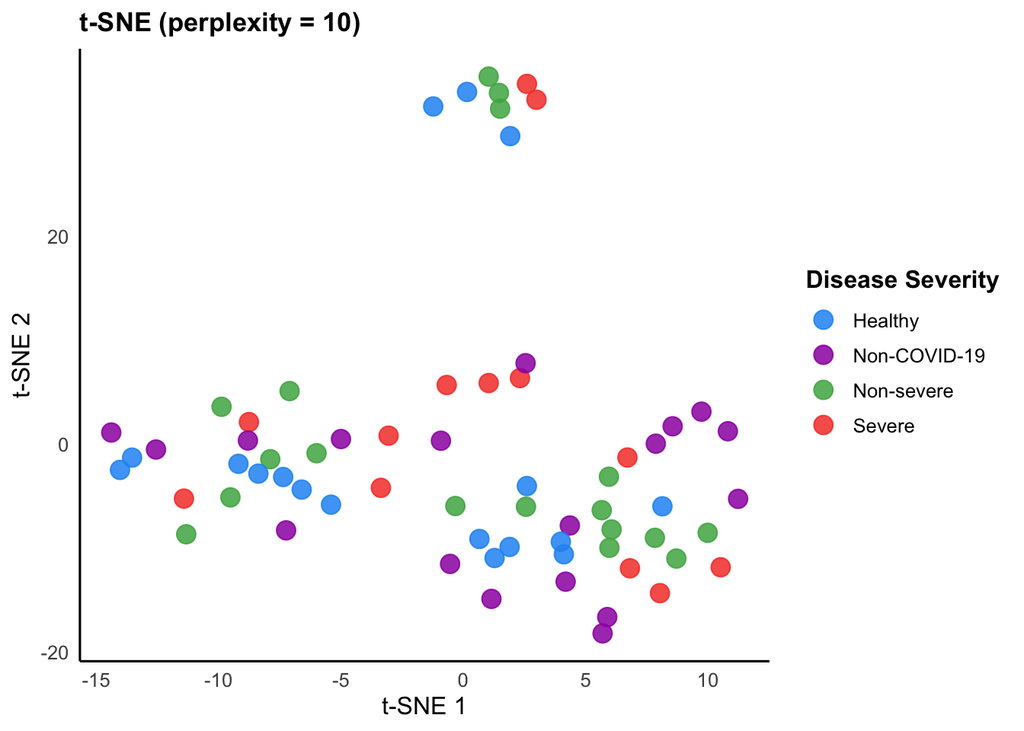

```r
print(p_tsne_low)
```

## UMAP

Perform UMAP on the proteomic data. Visualize the results, coloring samples by disease severity.

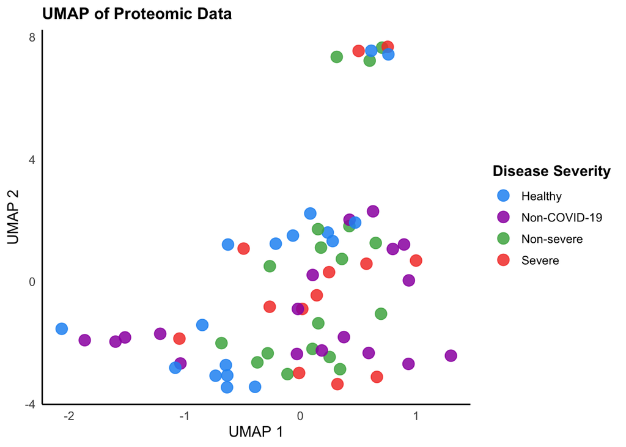

```r
set.seed(42)
umap_config <- umap.defaults
umap_config$n_neighbors <- 15
umap_config$min_dist <- 0.1
umap_result <- umap(protein_matrix_clean, config = umap_config)

umap_df <- data.frame(UMAP1 = umap_result$layout[, 1], UMAP2 = umap_result$layout[, 2], Sample = rownames(protein_matrix_clean))
umap_df$Severity <- sample_severity[umap_df$Sample]
umap_df <- umap_df[!is.na(umap_df$Severity), ]

p_umap <- ggplot(umap_df, aes(x = UMAP1, y = UMAP2, color = Severity)) +
  geom_point(size = 4, alpha = 0.85) +
  scale_color_manual(values = severity_colors) +
  theme_minimal(base_size = 12) +
  theme(
    panel.background = element_rect(fill = "white", color = NA),
    plot.background = element_rect(fill = "white", color = NA),
    panel.grid.major = element_blank(),
    panel.grid.minor = element_blank(),
    axis.line = element_line(color = "black"),
    plot.title = element_text(face = "bold", size = 13),
    legend.title = element_text(face = "bold")
  ) +
  labs(title = "UMAP of Proteomic Data", x = "UMAP 1", y = "UMAP 2", color = "Disease Severity")
print(p_umap)
```

> Contrary to the distinction observed in the PCA and clustering analyses, the non-linear dimensionality reduction techniques (t-SNE and UMAP) did not show clear clusters separated by disease severity. In both the high and low perplexity t-SNE plots and the UMAP projection, the four groups appeared mixed together.

> This difference in performance between the linear and non-linear methods could be for several reasons.

> First, it highlights the impact of the dataset size. As t-SNE and UMAP require a high volume of samples to find local topological neighborhoods, they struggled to form stable clusters.

> Second, it could suggest that the proteomic shift caused by COVID-19 severity is continuous and linear. PCA captured the linear transition from healthy to severe, while the non-linear methods resulted in collapsing the distinct clinical groups into a single heterogeneous one.

# Heatmap visualization

From Table S6 (Differentially Expressed Proteins and Metabolites), select the differentially expressed proteins between Severe and Healthy patients. Generate a heatmap of these proteins.

Add annotation tracks for:

- Group
- Gender
- Age

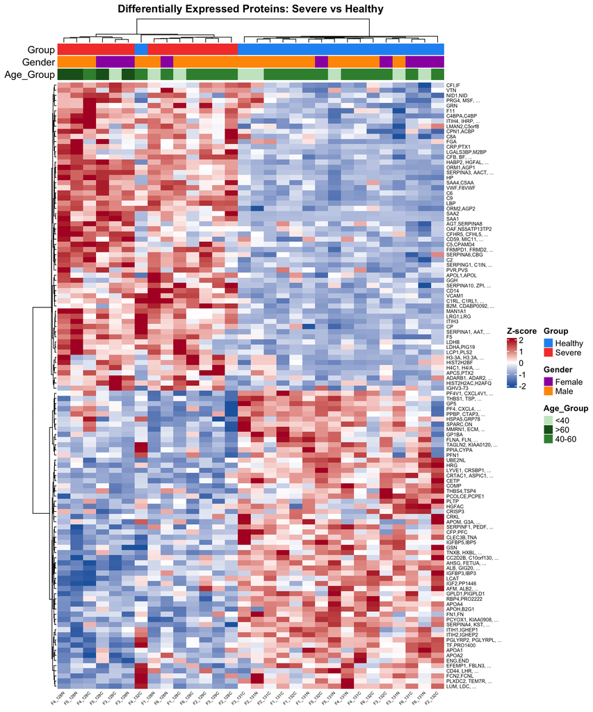

```r
table_s6 <- read_excel("table_s6.xlsx", sheet = "Prot Severe vs Healthy", skip = 1)
colnames(table_s6) <- c("Proteins", "Gene_Symbol", "fd", "P_value", "P_value_adj")

dep_proteins <- as.character(table_s6$Proteins)
dep_proteins <- dep_proteins[!is.na(dep_proteins)]
gene_symbols <- as.character(table_s6$Gene_Symbol)
matrix_cols <- colnames(protein_matrix_clean)

normalize_name <- function(x) toupper(trimws(x))

dep_proteins_in_matrix <- c()
for (i in seq_along(dep_proteins)) {
  genes <- normalize_name(trimws(strsplit(gene_symbols[i], ",")[[1]]))
  matched <- matrix_cols[sapply(matrix_cols, function(col) {
    col_genes <- normalize_name(trimws(strsplit(col, ",")[[1]]))
    any(genes %in% col_genes)
  })]
  if (length(matched) > 0) dep_proteins_in_matrix <- c(dep_proteins_in_matrix, matched[1])
}
dep_proteins_in_matrix <- unique(dep_proteins_in_matrix)

if (length(dep_proteins_in_matrix) > 0) {
  heatmap_matrix <- t(protein_matrix_clean[, dep_proteins_in_matrix, drop = FALSE])

  severe_samples <- names(sample_severity)[sample_severity == "Severe"]
  healthy_samples <- names(sample_severity)[sample_severity == "Healthy"]
  patients_for_heatmap <- c(severe_samples, healthy_samples)
  patients_available <- intersect(patients_for_heatmap, colnames(heatmap_matrix))
  heatmap_matrix <- heatmap_matrix[, patients_available, drop = FALSE]

  heatmap_matrix_scaled <- t(scale(t(heatmap_matrix)))
  row_var_hm <- apply(heatmap_matrix_scaled, 1, var, na.rm = TRUE)
  heatmap_matrix_scaled <- heatmap_matrix_scaled[!is.na(row_var_hm) & row_var_hm > 1e-10, ]

  severity_col <- sample_severity[patients_available]
  sex_col <- as.character(clinical$`Sex g`[match(ms_to_patient[patients_available], clinical$`Patient ID a`)])
  sex_col <- ifelse(sex_col == "0", "Female", "Male")
  age_col <- clinical$`Age (year)`[match(ms_to_patient[patients_available], clinical$`Patient ID a`)]
  age_group <- ifelse(is.na(age_col), NA, ifelse(age_col < 40, "<40", ifelse(age_col <= 60, "40-60", ">60")))

  annotation_df <- data.frame(
    Group = severity_col,
    Gender = sex_col,
    Age_Group = age_group,
    row.names = patients_available
  )
  annotation_df <- annotation_df[!is.na(annotation_df$Group), ]
  heatmap_matrix_scaled <- heatmap_matrix_scaled[, rownames(annotation_df), drop = FALSE]

  clean_row_names <- sapply(rownames(heatmap_matrix_scaled), function(name) {
    genes <- trimws(strsplit(name, ",")[[1]])
    if (length(genes) > 2) {
      return(paste0(genes[1], ", ", genes[2], ", ..."))
    } else {
      return(name)
    }
  })
  rownames(heatmap_matrix_scaled) <- clean_row_names

  ha <- HeatmapAnnotation(
    df = annotation_df,
    col = list(
      Group = c("Healthy" = "#2196F3", "Severe" = "#F44336"),
      Gender = c("Female" = "#9C27B0", "Male" = "#FF9800"),
      Age_Group = c("<40" = "#C8E6C9", "40-60" = "#388E3C", ">60" = "#1B5E20")
    ),
    annotation_name_side = "left",
    annotation_height = unit(3, "mm")
  )

  col_fun <- colorRamp2(c(-2, 0, 2), c("#2166AC", "white", "#B2182B"))

  ht <- Heatmap(
    heatmap_matrix_scaled,
    name = "Z-score",
    col = col_fun,
    top_annotation = ha,
    show_column_names = TRUE,

    column_names_rot = 45,
    column_names_gp = gpar(fontsize = 5),

    show_row_names = TRUE,
    row_names_gp = gpar(fontsize = 6),
    clustering_distance_rows = "euclidean",
    clustering_method_rows = "ward.D2",
    clustering_distance_columns = "euclidean",
    clustering_method_columns = "ward.D2",
    column_title = "Differentially Expressed Proteins: Severe vs Healthy",
    column_title_gp = gpar(fontsize = 13, fontface = "bold")
  )

  draw(ht)
}
```

```r
# DEP overlap with top 50 PC1 and PC2
top50_pc1 <- rownames(loadings)[order(abs(loadings[, 1]), decreasing = TRUE)[1:50]]
top50_pc2 <- rownames(loadings)[order(abs(loadings[, 2]), decreasing = TRUE)[1:50]]

overlap_pc1 <- dep_proteins_in_matrix[sapply(dep_proteins_in_matrix, function(p) {
  any(normalize_name(trimws(strsplit(p, ",")[[1]])) %in% normalize_name(trimws(strsplit(paste(top50_pc1, collapse = ","), ",")[[1]])))
})]

overlap_pc2 <- dep_proteins_in_matrix[sapply(dep_proteins_in_matrix, function(p) {
  any(normalize_name(trimws(strsplit(p, ",")[[1]])) %in% normalize_name(trimws(strsplit(paste(top50_pc2, collapse = ","), ",")[[1]])))
})]

cat("DEPs in top 50 PC1 contributors:", length(overlap_pc1), "\n")
```

```
## DEPs in top 50 PC1 contributors: 4
```

```r
if (length(overlap_pc1) > 0) cat(overlap_pc1, sep = "\n")
```

```
## VWF,F8VWF
## VCAM1
## EFEMP1,FBLN3,FBNL
## LYVE1,CRSBP1,HAR,XLKD1,UNQ230/PRO263
```

```r
cat("DEPs in top 50 PC2 contributors:", length(overlap_pc2), "\n")
```

```
## DEPs in top 50 PC2 contributors: 42
```

```r
if (length(overlap_pc2) > 0) cat(overlap_pc2, sep = "\n")
```

```
## CP
## C5,CPAMD4
## SERPINA1,AAT,PI,PRO0684,PRO2209
## HP
## ITIH4,IHRP,ITIHL1,PK120,PRO1851
## CFB,BF,BFD
## C6
## SERPINA3,AACT,GIG24,GIG25
## F5
## C4BPA,C4BP
## ITIH3
## C2
## CFI,IF
## SERPING1,C1IN,C1NH
## C9
## ORM1,AGP1
## LCP1,PLS2
## ORM2,AGP2
## AGT,SERPINA8
## CFHR5,CFHL5,FHR5
## F11
## LRG1,LRG
## CPN1,ACBP
## SAA1
## LBP
## APCS,PTX2
## SERPINA10,ZPI,UNQ707/PRO1358
## SAA2
## CD14
## SAA4,CSAA
## OAF,NS5ATP13TP2
## LDHA,PIG19
## B2M,CDABP0092,HDCMA22P
## ALB,GIG20,GIG42,PRO0903,PRO1708,PRO2044,PRO2619,PRO2675,UNQ696/PRO1341
## GSN
## APOA4
## AHSG,FETUA,PRO2743
## LUM,LDC,SLRR2D
## CLEC3B,TNA
## TNXB,HXBL,TNX,TNXB1,TNXB2,XB
## CFP,PFC
## CRTAC1,ASPIC1,CEP68
```

Comment on any visible patterns or associations between protein expression and the annotations.

Are these proteins among the top contributors to PC1 or PC2? Use the top 50 proteins contributing to PC1 and PC2 to support your interpretation.

> The heatmap shows the expression patterns of differentially expressed proteins (DEPs) between severe and healthy patients, including severity, gender, and age group annotations.

> Considering the separation by disease severity, healthy samples cluster together and show higher expression for a large set of proteins situated mainly in the lower half of the heatmap. On the other hand, severe patients also cluster together and show higher expression for another set of proteins situated mainly in the upper half of the heatmap. Proteins highly expressed in healthy patietns show lower expressions in severe patients, and vice versa.

> In contrast, gender and age annotations do not show a clear clustering pattern. Both males and females appear mixed through all the heatmap. The patients corresponding higher age group appear more to the left of the heatmap, but there are no clear differences between the other age groups.

> These results of the heatmap suggest that disease severity is the dominant driver of the protein expression differences, while age and gender do not contribute much to the clustering.

# session info

R version 4.5.1 (2025-06-13) Platform: aarch64-apple-darwin20 Running under: macOS Sonoma 14.4.1

Matrix products: default BLAS: /Library/Frameworks/R.framework/Versions/4.5-arm64/Resources/lib/libRblas.0.dylib LAPACK: /Library/Frameworks/R.framework/Versions/4.5-arm64/Resources/lib/libRlapack.dylib; LAPACK version 3.12.1

locale: [1] en_US.UTF-8/en_US.UTF-8/en_US.UTF-8/C/en_US.UTF-8/en_US.UTF-8

time zone: Europe/Madrid tzcode source: internal

attached base packages: [1] grid stats graphics grDevices utils datasets methods  
[8] base

other attached packages: [1] circlize_0.4.17 ComplexHeatmap_2.26.1 RColorBrewer_1.1-3  
[4] umap_0.2.10.0 Rtsne_0.17 dendextend_1.19.1  
[7] ggpubr_0.6.3 factoextra_2.0.0 cluster_2.1.8.2  
[10] tibble_3.3.1 ggplot2_4.0.2 dplyr_1.2.0  
[13] readxl_1.4.5

loaded via a namespace (and not attached): [1] tidyselect_1.2.1 viridisLite_0.4.3 farver_2.1.2  
[4] viridis_0.6.5 S7_0.2.1 fastmap_1.2.0  
[7] digest_0.6.39 lifecycle_1.0.5 magrittr_2.0.4  
[10] compiler_4.5.1 rlang_1.1.7 sass_0.4.10  
[13] tools_4.5.1 yaml_2.3.12 knitr_1.51  
[16] ggsignif_0.6.4 labeling_0.4.3 askpass_1.2.1  
[19] reticulate_1.45.0 abind_1.4-8 withr_3.0.2  
[22] purrr_1.2.1 BiocGenerics_0.56.0 stats4_4.5.1  
[25] colorspace_2.1-2 scales_1.4.0 iterators_1.0.14  
[28] cli_3.6.5 rmarkdown_2.30 crayon_1.5.3  
[31] generics_0.1.4 otel_0.2.0 rstudioapi_0.18.0  
[34] RSpectra_0.16-2 rjson_0.2.23 cachem_1.1.0  
[37] parallel_4.5.1 cellranger_1.1.0 matrixStats_1.5.0  
[40] vctrs_0.7.1 Matrix_1.7-4 jsonlite_2.0.0  
[43] carData_3.0-6 car_3.1-5 IRanges_2.44.0  
[46] GetoptLong_1.1.0 S4Vectors_0.48.0 rstatix_0.7.3  
[49] ggrepel_0.9.7 Formula_1.2-5 clue_0.3-67  
[52] foreach_1.5.2 tidyr_1.3.2 jquerylib_0.1.4  
[55] glue_1.8.0 codetools_0.2-20 gtable_0.3.6  
[58] shape_1.4.6.1 pillar_1.11.1 htmltools_0.5.9  
[61] openssl_2.3.5 R6_2.6.1 doParallel_1.0.17  
[64] evaluate_1.0.5 lattice_0.22-9 png_0.1-8  
[67] backports_1.5.0 broom_1.0.12 bslib_0.10.0  
[70] Rcpp_1.1.1 gridExtra_2.3 xfun_0.56  
[73] pkgconfig_2.0.3 GlobalOptions_0.1.3